# Plotting the data with R

# Introduction

We look at some of the ways R can display information graphically, after dealing with our dataset on R session. Here, I will introduce some basic plotting commands with *built-in dataset*, called **airquality**. In other words, we do not need any data import in this time.

```r
str(airquality)
```

```
'data.frame':   153 obs. of  6 variables:
 $ Ozone  : int  41 36 12 18 NA 28 23 19 8 NA ...
 $ Solar.R: int  190 118 149 313 NA NA 299 99 19 194 ...
 $ Wind   : num  7.4 8 12.6 11.5 14.3 14.9 8.6 13.8 20.1 8.6 ...
 $ Temp   : int  67 72 74 62 56 66 65 59 61 69 ...
 $ Month  : int  5 5 5 5 5 5 5 5 5 5 ...
 $ Day    : int  1 2 3 4 5 6 7 8 9 10 ...
```

# Basic plot

## Strip Charts

A strip chart is the most basic type of plot available. It plots the data in order along a line with each data point represented as a box. Since we have imported data, we will make a strip chart for ozone reading.

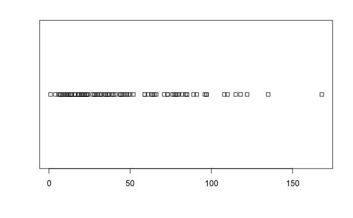

```r
stripchart(airquality$Ozone)
```

We can see that the data is mostly cluttered below 50 with one falling outside 150. However, we could pass some additional parameters to control the way how plot looks like. You can read about them in the help section by using question mark.

## Adjust strip chart

Some of the frequently used ones are, **main** to give the title, **xlab and ylab** to provide labels for the axes, **method** to specify the way coincident points are plotted like stacked or jitter, **col** to define color etc. Additionally, with the argument **vertical=TRUE** we can plot it vertically and with pch we can specify the plotting character (square by default). Some values of **pch** are 0 for square, 1 for circle, 2 for triangle etc. You can see the full list in the help section *?points*.

What if we try to use several parameters? Let’s try to setting the **jitter** for the method and giving details.

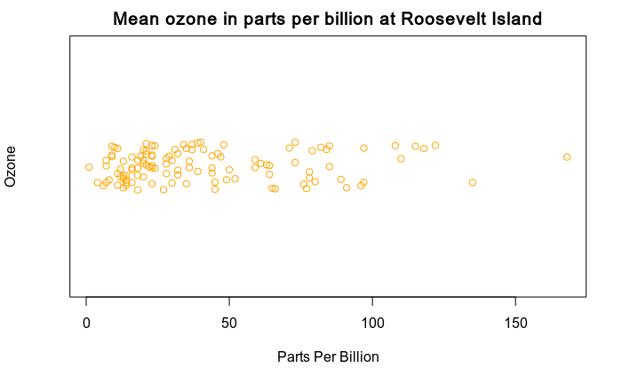

```r
stripchart(airquality$Ozone,
main="Mean ozone in parts per billion at Roosevelt Island",
xlab="Parts Per Billion",
ylab="Ozone",
method="jitter",
col="orange",
pch=1
)
```

## Multiple Strip Charts

We can draw multiple strip charts in a single plot, by passing in a list of numeric vectors.

Let us consider the *Temp* field of *airquality* dataset. Let us also generate normal distribution with the same mean and standard deviation and plot them side by side for comparison.

```r
# prepare the data
temp <- airquality$Temp
# gererate normal distribution with same mean and sd
tempNorm <- rnorm(200,mean=mean(temp, na.rm=TRUE), sd = sd(temp, na.rm=TRUE))
# make a list
x <- list("temp"=temp, "norm"=tempNorm)
```

Now we us make two stripcharts with this list in one chart.

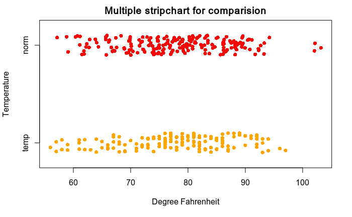

```r
stripchart(x,
main="Multiple stripchart for comparision",
xlab="Degree Fahrenheit",
ylab="Temperature",
method="jitter",
col=c("orange","red"),
pch=16
)
```

## Strip Chart from Formula

Stripchart function also takes in formulas of the form **y ~ x** where, y is a numeric vector which is grouped according to the value of x. For example, in our dataset airquality, the Temp can be our numeric vector. Month can be our grouping variable, so that we get the strip chart for each month separately. In airquality dataset, month is in the form of number (1=January, 2-Febuary and so on).

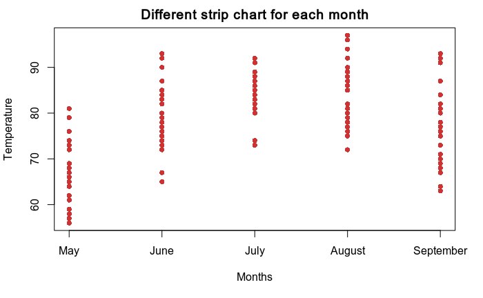

```r
stripchart(Temp~Month,
data=airquality,
main="Different strip chart for each month",
xlab="Months",
ylab="Temperature",
col="brown3",
group.names=c("May","June","July","August","September"),
vertical=TRUE,
pch=16
)
```

# Boxplot

A boxplot provides a graphical view of the median, quartiles, maximum, and minimum of a data set, by taking in any number of numeric vectors.

Let’s start with the basic boxplot with Ozone readings from airquality data.

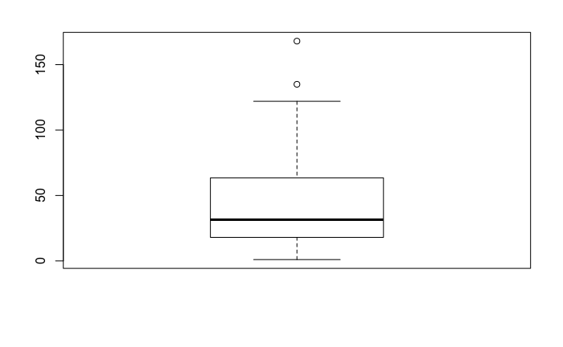

```r
boxplot(airquality$Ozone)
```

We can see that data above the median is more dispersed. We can also notice two outliers at the higher extreme. Like strip chart, we could adjust parameters with same parameters we used.

## Adjusting the plot

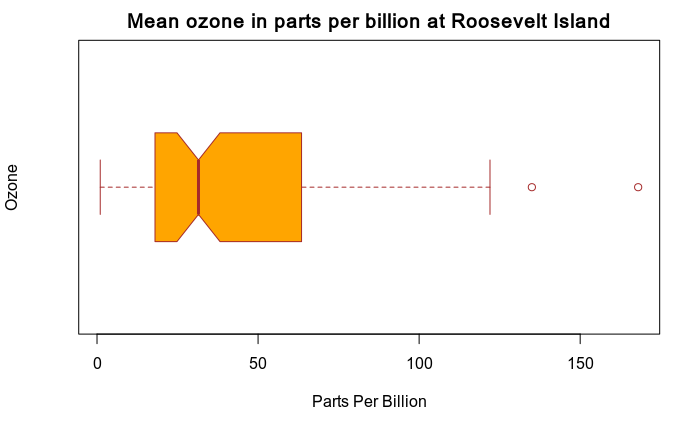

```r
boxplot(airquality$Ozone,
main = "Mean ozone in parts per billion at Roosevelt Island",
xlab = "Parts Per Billion",
ylab = "Ozone",
col = "orange",
border = "brown",
horizontal = TRUE,
notch = TRUE
)
```

## Return the value of boxplot

What if we would like to return the values plotted on boxplot? Here, we could get some information regarding the values on the boxplot by giving the variable to the plot.

```r
b
```

[output not shown]

```
$stats
      [,1]
[1,]   1.0
[2,]  18.0
[3,]  31.5
[4,]  63.5
[5,] 122.0
attr(,"class")
        1
"integer"

$n
[1] 116

$conf
         [,1]
[1,] 24.82518
[2,] 38.17482

$out
[1] 135 168

$group
[1] 1 1

$names
[1] "1"
```

As we could see above, a list is returned. - stats: position of the upper/lower extremes of the whiskers and box along the median - n: the number of observations the boxplot is drawn with (NA value is not counted) - conf: upper/lower extremes of the notch - out: value of the outliers - group: a vector of the same length as out whose elements indicate to which group the outlier belongs - names: a vector of names for the groups

## Multiple plots

We can draw multiple boxplots in a single plot, by passing in a list, data frame or multiple vectors, as we did on strip chart. Let us consider the Ozone and Temp field of airquality dataset. Let us also generate normal distribution with the same mean and standard deviation and plot them side by side for comparison.

```r
# prepare the data
ozone <- airquality$Ozone
temp <- airquality$Temp
# gererate normal distribution with same mean and sd
ozone_norm <- rnorm(200,mean=mean(ozone, na.rm=TRUE), sd=sd(ozone, na.rm=TRUE))
temp_norm <- rnorm(200,mean=mean(temp, na.rm=TRUE), sd=sd(temp, na.rm=TRUE))
```

Now we us make 4 boxplots with this data. We use the arguments **at** and **names** to denote the place and label.

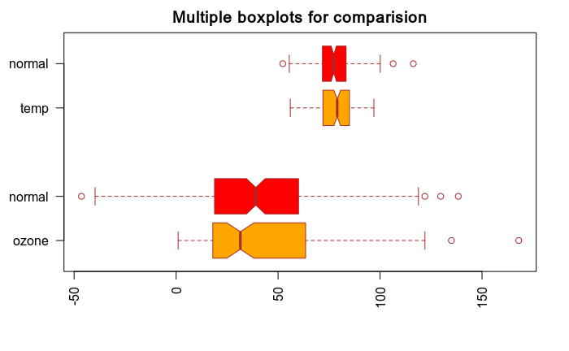

```r
boxplot(ozone, ozone_norm, temp, temp_norm,
main = "Multiple boxplots for comparision",
at = c(1,2,4,5),
names = c("ozone", "normal", "temp", "normal"),
las = 2,
col = c("orange","red"),
border = "brown",
horizontal = TRUE,
notch = TRUE
)
```

## Boxplot from formula

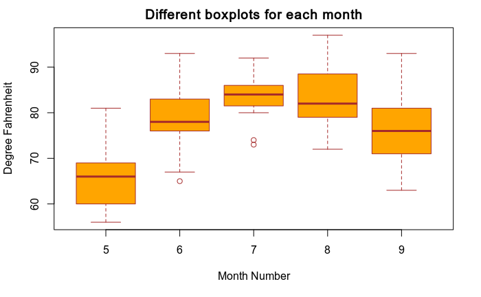

```r
boxplot(Temp~Month,
data=airquality,
main="Different boxplots for each month",
xlab="Month Number",
ylab="Degree Fahrenheit",
col="orange",
border="brown"
)
```

# Histogram

A histogram is very common plot. It plots the frequencies that data appears within certain ranges. On R, histogram can be created using the *hist()* function. This function takes in a vector of values for which the histogram is plotted.

## Simple histogram

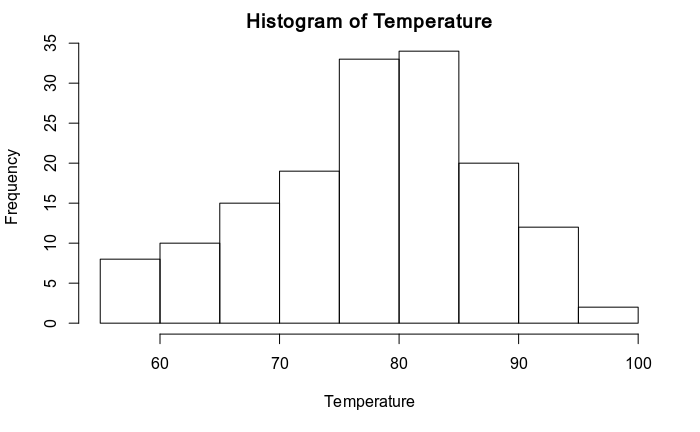

```r
Temperature <- airquality$Temp
hist(Temperature)
```

We can see above that there are 9 cells with equally spaced breaks. In this case, the height of a cell is equal to the number of observation falling in that cell.